# Adidas_Marketing_Project

## **Adidas Marketing Analysis**

## Sai Anudeep Janapareddy - W0836698

```python
import pandas as pd
import numpy as np
import matplotlib.pyplot as plt
import seaborn as sns
from datetime import datetime
from sklearn.preprocessing import LabelEncoder
from sklearn.model_selection import train_test_split
from sklearn.ensemble import RandomForestRegressor
from sklearn.metrics import mean_absolute_error, mean_squared_error, r2_score
```

```python
sales = pd.read_excel('Adidas Sales Datasets.xlsx', engine='openpyxl')
sales.head(10)
```

|  | Retailer | Retailer ID | Invoice Date | Region | State | City | Product | Price per Unit | Units Sold | Total Sales | Operating Profit | Operating Margin | Sales Method |
| --- | --- | --- | --- | --- | --- | --- | --- | --- | --- | --- | --- | --- | --- |
| 0 | Foot Locker | 1185732 | 2020-01-01 | Northeast | New York | New York | Men's Street Footwear | 50.0 | 1200 | 600000.0 | 300000.0 | 0.50 | In-store |
| 1 | West Gear | 1128299 | 2021-01-01 | West | California | San Francisco | Men's Athletic Footwear | 65.0 | 750 | 487500.0 | 121875.0 | 0.25 | Outlet |
| 2 | West Gear | 1128299 | 2021-01-02 | West | California | San Francisco | Women's Street Footwear | 65.0 | 750 | 487500.0 | 195000.0 | 0.40 | Outlet |
| 3 | West Gear | 1128299 | 2021-01-03 | West | California | San Francisco | Women's Athletic Footwear | 60.0 | 650 | 390000.0 | 136500.0 | 0.35 | Outlet |
| 4 | West Gear | 1128299 | 2021-01-04 | West | California | San Francisco | Men's Apparel | 65.0 | 550 | 357500.0 | 196625.0 | 0.55 | Outlet |
| 5 | West Gear | 1128299 | 2021-01-05 | West | California | San Francisco | Women's Apparel | 80.0 | 725 | 580000.0 | 116000.0 | 0.20 | Outlet |
| 6 | West Gear | 1128299 | 2021-01-06 | West | California | San Francisco | Men's Street Footwear | 60.0 | 975 | 585000.0 | 234000.0 | 0.40 | Outlet |
| 7 | West Gear | 1128299 | 2021-01-07 | West | California | San Francisco | Men's Athletic Footwear | 65.0 | 825 | 536250.0 | 134062.5 | 0.25 | Outlet |
| 8 | West Gear | 1128299 | 2021-01-08 | West | California | San Francisco | Women's Street Footwear | 65.0 | 825 | 536250.0 | 214500.0 | 0.40 | Outlet |
| 9 | West Gear | 1128299 | 2021-01-09 | West | California | San Francisco | Women's Athletic Footwear | 60.0 | 700 | 420000.0 | 147000.0 | 0.35 | Outlet |

```python
sales.columns
```

```
Index(['Retailer', 'Retailer ID', 'Invoice Date', 'Region', 'State', 'City',
       'Product', 'Price per Unit', 'Units Sold', 'Total Sales',
       'Operating Profit', 'Operating Margin', 'Sales Method'],
      dtype='object')
```

```python
print(sales.isnull().sum())
```

```
Retailer            0
Retailer ID         0
Invoice Date        0
Region              0
State               0
City                0
Product             0
Price per Unit      0
Units Sold          0
Total Sales         0
Operating Profit    0
Operating Margin    0
Sales Method        0
dtype: int64
```

```python
sales.shape
```

```
(9649, 13)
```

```python
# Convert 'Invoice Date' to datetime
sales['Invoice Date'] = pd.to_datetime(sales['Invoice Date'])

# Extract year, month, and day from 'Invoice Date'
sales['Year'] = sales['Invoice Date'].dt.year
sales['Month'] = sales['Invoice Date'].dt.month


# Create 'Season' column based on month
def get_season(month):
    if month in [12, 1, 2]:
        return 'Winter'
    elif month in [3, 4, 5]:
        return 'Spring'
    elif month in [6, 7, 8]:
        return 'Summer'
    else:
        return 'Autumn'

sales['Season'] = sales['Month'].apply(get_season)
```

```python
# Remove rows with zero 'Units Sold'
sales = sales[sales['Units Sold'] != 0]
```

```python
# Clean 'Product' column
sales['Product'] = sales['Product'].str.strip().str.title()
```

```python
# Select columns for analysis (replace with your desired columns)
selected_columns = ['Retailer','Retailer ID', 'Region', 'State', 'City', 'Product']

# Calculate and print the number of unique values for each selected column
for col in selected_columns:
  print(f"Number of unique values in '{col}': {sales[col].nunique()}")
```

```
Number of unique values in 'Retailer': 6
Number of unique values in 'Retailer ID': 4
Number of unique values in 'Region': 5
Number of unique values in 'State': 50
Number of unique values in 'City': 52
Number of unique values in 'Product': 6
```

```python
# Check for Retailer IDs associated with multiple Retailers
multiple_retailers = sales.groupby('Retailer ID')['Retailer'].nunique() > 1
if multiple_retailers.any():
    print("\nRetailer IDs associated with multiple Retailers:")
    print(sales[sales['Retailer ID'].isin(multiple_retailers[multiple_retailers].index)][['Retailer', 'Retailer ID']].drop_duplicates())
```

```
Retailer IDs associated with multiple Retailers:
           Retailer  Retailer ID
0       Foot Locker      1185732
1         West Gear      1128299
192   Sports Direct      1197831
619          Amazon      1185732
758     Foot Locker      1128299
804         Walmart      1128299
826   Sports Direct      1128299
902       West Gear      1185732
970          Kohl's      1185732
1118  Sports Direct      1185732
1478    Foot Locker      1197831
1483      West Gear      1197831
1618         Kohl's      1128299
2091        Walmart      1185732
2135        Walmart      1197831
2257         Kohl's      1197831
```

```python
sales = sales.drop('Retailer ID', axis=1)
```

```python
def extract_gender(product):
    # Split the product name and take the first word
    first_word = product.split()[0]

    # Remove apostrophe if present
    first_word = first_word.replace("'", "")

    # Remove 'S' at the end if present
    if first_word.endswith('S'):
        first_word = first_word[:-1]

    return first_word

# Create the 'Gender' column
sales['Gender'] = sales['Product'].apply(extract_gender)

# Convert 'Gender' to categorical
sales['Gender'] = sales['Gender'].astype('category')

print(sales[['Product', 'Gender']].head())

# Check the unique values in the Gender column
print("\nUnique values in Gender column:")
print(sales['Gender'].unique())
```

```
                     Product Gender
0      Men'S Street Footwear    Men
1    Men'S Athletic Footwear    Men
2    Women'S Street Footwear  Women
3  Women'S Athletic Footwear  Women
4              Men'S Apparel    Men

Unique values in Gender column:
['Men', 'Women']
Categories (2, object): ['Men', 'Women']
```

```python
sales = sales.drop_duplicates()
sales.shape
```

```
(9644, 16)
```

```python
sales = sales.dropna()
sales = sales.reset_index(drop=True)
sales.head()
```

|  | Retailer | Invoice Date | Region | State | City | Product | Price per Unit | Units Sold | Total Sales | Operating Profit | Operating Margin | Sales Method | Year | Month | Season | Gender |
| --- | --- | --- | --- | --- | --- | --- | --- | --- | --- | --- | --- | --- | --- | --- | --- | --- |
| 0 | Foot Locker | 2020-01-01 | Northeast | New York | New York | Men'S Street Footwear | 50.0 | 1200 | 600000.0 | 300000.0 | 0.50 | In-store | 2020 | 1 | Winter | Men |
| 1 | West Gear | 2021-01-01 | West | California | San Francisco | Men'S Athletic Footwear | 65.0 | 750 | 487500.0 | 121875.0 | 0.25 | Outlet | 2021 | 1 | Winter | Men |
| 2 | West Gear | 2021-01-02 | West | California | San Francisco | Women'S Street Footwear | 65.0 | 750 | 487500.0 | 195000.0 | 0.40 | Outlet | 2021 | 1 | Winter | Women |
| 3 | West Gear | 2021-01-03 | West | California | San Francisco | Women'S Athletic Footwear | 60.0 | 650 | 390000.0 | 136500.0 | 0.35 | Outlet | 2021 | 1 | Winter | Women |
| 4 | West Gear | 2021-01-04 | West | California | San Francisco | Men'S Apparel | 65.0 | 550 | 357500.0 | 196625.0 | 0.55 | Outlet | 2021 | 1 | Winter | Men |

```python
categorical_columns = sales.select_dtypes(include=['object']).columns.tolist()
# Display the categorical columns
categorical_columns
```

```
['Retailer', 'Region', 'State', 'City', 'Product', 'Sales Method', 'Season']
```

```python
# Group by StockCode and sum the Quantity
products = sales.groupby('Product')['Units Sold'].sum().reset_index()

# Sort the results by Quantity in descending order
Products_and_quantity = products.sort_values(by='Units Sold', ascending=False)

# Display the top 10 products
print(Products_and_quantity)
```

```
                     Product  Units Sold
2      Men'S Street Footwear      593320
1    Men'S Athletic Footwear      435526
3            Women'S Apparel      433827
5    Women'S Street Footwear      392269
4  Women'S Athletic Footwear      317236
0              Men'S Apparel      306683
```

### Plot 1

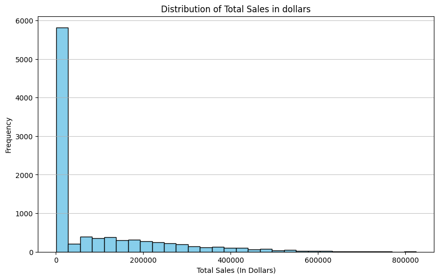

```python
# Plot the histogram for TotalPrice
plt.figure(figsize=(10, 6))
plt.hist(sales['Total Sales'], bins=30, color='skyblue', edgecolor='black')
plt.title('Distribution of Total Sales in dollars')
plt.xlabel('Total Sales (In Dollars)')
plt.ylabel('Frequency')
plt.grid(axis='y', alpha=0.75)
plt.show()
```

### Plot 2

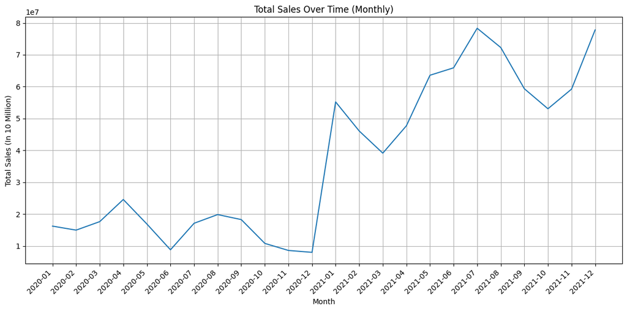

```python
# Total Sales Over Time
# Create a 'YearMonth' column for grouping
sales['YearMonth'] = sales['Invoice Date'].dt.to_period('M')

# Group by 'YearMonth' and sum 'Total Sales'
total_sales_over_time = sales.groupby('YearMonth')['Total Sales'].sum()

# Plot the line graph
plt.figure(figsize=(12, 6))
plt.plot(total_sales_over_time.index.astype(str), total_sales_over_time.values)
plt.xlabel('Month')
plt.ylabel('Total Sales (In 10 Million)')
plt.title('Total Sales Over Time (Monthly)')
plt.xticks(rotation=45, ha='right')  # Rotate x-axis labels for better readability
plt.grid(True)
plt.tight_layout()
plt.show()
```

### Plot 3

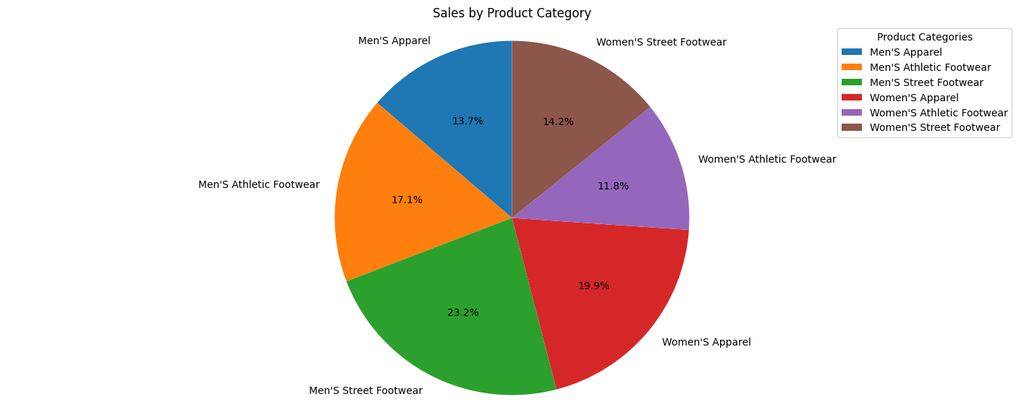

```python
# Sales by Product Category
# Group by Product Category and sum the Total Sales
sales_by_category = sales.groupby('Product')['Total Sales'].sum()

# Create a pie chart
plt.figure(figsize=(18, 7))
plt.pie(sales_by_category, labels=sales_by_category.index, autopct='%1.1f%%', startangle=90)
plt.title('Sales by Product Category')
plt.axis('equal')  # Equal aspect ratio ensures that pie is drawn as a circle.

# Add a legend
plt.legend(title='Product Categories', loc='upper right')

plt.show()
```

### Plot 4

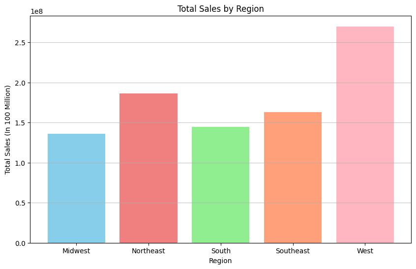

```python
# Sales by Region
# Group by Region and sum the Total Sales
sales_by_region = sales.groupby('Region')['Total Sales'].sum()

# Create a bar graph
plt.figure(figsize=(10, 6))
plt.bar(sales_by_region.index, sales_by_region.values, color=['skyblue', 'lightcoral', 'lightgreen', 'lightsalmon', 'lightpink'])
plt.xlabel('Region')
plt.ylabel('Total Sales (In 100 Million)')
plt.title('Total Sales by Region')
plt.xticks(rotation=0)  # Rotate x-axis labels for better readability
plt.grid(axis='y', alpha=0.75)
plt.show()
```

### Plot 5

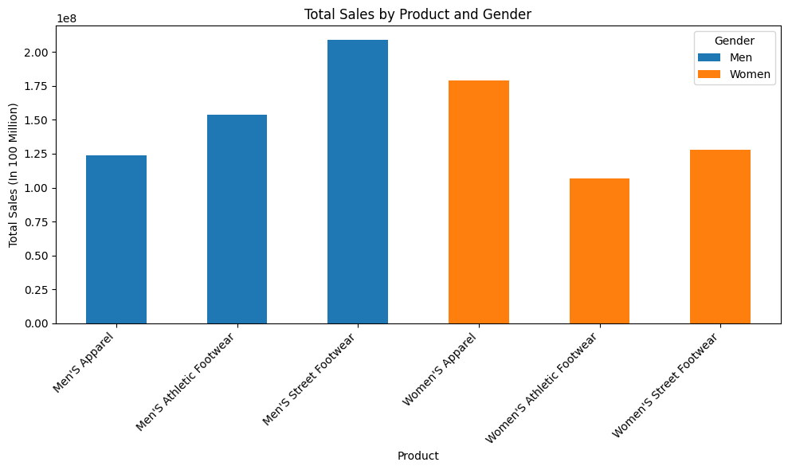

```python
# Group the data by 'Product' and 'Gender' and sum 'Total Sales'
sales_by_product_gender = sales.groupby(['Product', 'Gender'])['Total Sales'].sum().unstack()

# Bar chart using Matplotlib
sales_by_product_gender.plot(kind='bar',stacked=True, figsize=(10, 6))
plt.title('Total Sales by Product and Gender')
plt.xlabel('Product')
plt.ylabel('Total Sales (In 100 Million)')
plt.legend(title='Gender')
plt.xticks(rotation=45, ha='right')
plt.legend(title='Gender')
plt.tight_layout()
plt.show()
```

### Plot 6

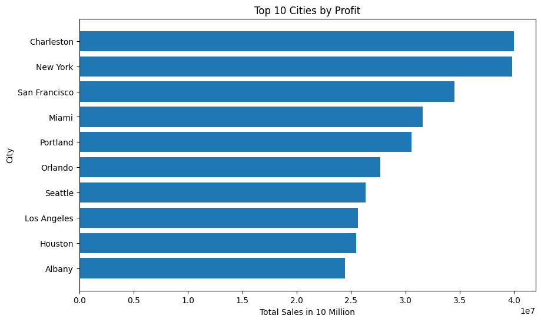

```python
# Top 10 Cities by Profit
# Group by city and sum total sales
city_sales = sales.groupby('City')['Total Sales'].sum()

# Sort cities by total sales in descending order
top_cities = city_sales.sort_values(ascending=False).head(10)

# Create the horizontal bar chart
plt.figure(figsize=(10, 6))
plt.barh(top_cities.index, top_cities.values)
plt.xlabel('Total Sales in 10 Million')
plt.ylabel('City')
plt.title('Top 10 Cities by Profit')
plt.gca().invert_yaxis()  # Invert y-axis to show highest sales at the top
plt.show()
```

### Plot 7

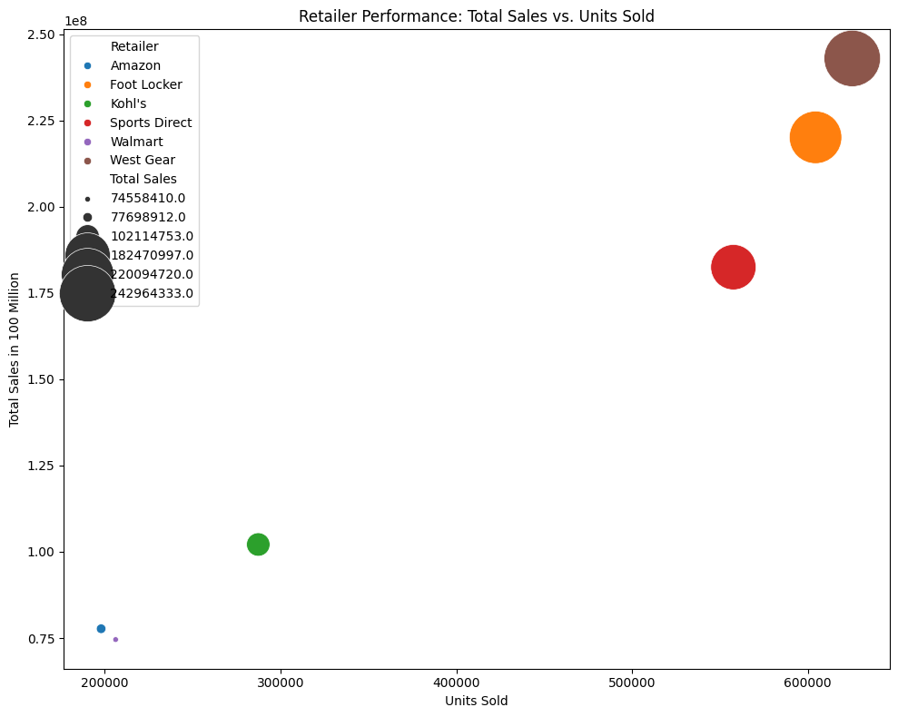

```python
# Assuming 'sales' is your original DataFrame
retailer_sales = sales.groupby('Retailer').agg({'Total Sales': 'sum', 'Units Sold': 'sum'}).reset_index()

plt.figure(figsize=(10, 8))
sns.scatterplot(data=retailer_sales,
                x='Units Sold',
                y='Total Sales',
                size='Total Sales',
                hue='Retailer',
                sizes=(20, 2000),legend=True)

plt.title('Retailer Performance: Total Sales vs. Units Sold')
plt.xlabel('Units Sold')
plt.ylabel('Total Sales in 100 Million')

plt.tight_layout()
plt.show()
```

### Plot 8

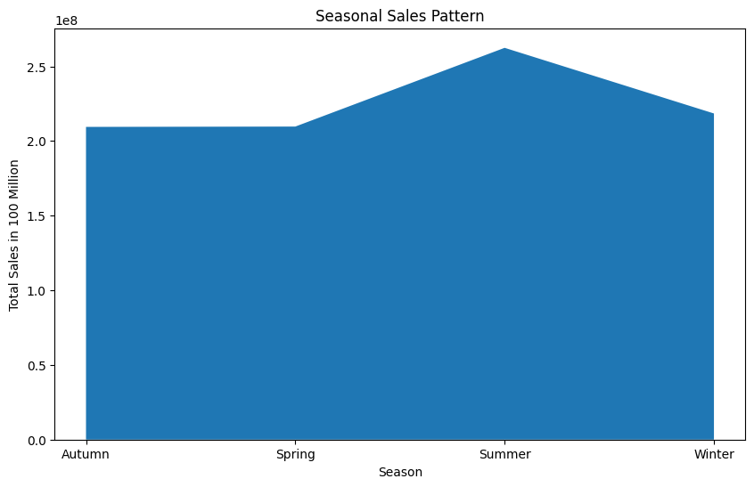

```python
# Seasonal Sales Pattern
# Group the data by season and sum total sales
seasonal_sales = sales.groupby('Season')['Total Sales'].sum()

# Create the area chart
plt.figure(figsize=(10, 6))
plt.stackplot(seasonal_sales.index, seasonal_sales.values, labels=seasonal_sales.index)
plt.title('Seasonal Sales Pattern')
plt.xlabel('Season')
plt.ylabel('Total Sales in 100 Million')
plt.show()
```

### Plot 9

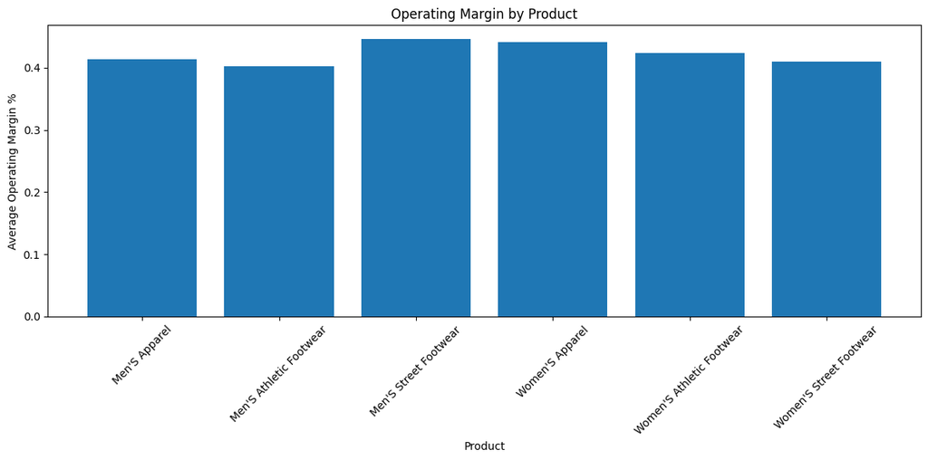

```python
# Operating Margin by Product
# Group by Product and calculate the average operating margin
average_operating_margin_by_product = sales.groupby('Product')['Operating Margin'].mean()

# Bar graph
plt.figure(figsize=(12, 6))
plt.bar(average_operating_margin_by_product.index, average_operating_margin_by_product.values)
plt.xlabel('Product')
plt.ylabel('Average Operating Margin %')
plt.title('Operating Margin by Product')
plt.xticks(rotation=45)
plt.tight_layout()
plt.show()
```

### Plot 10

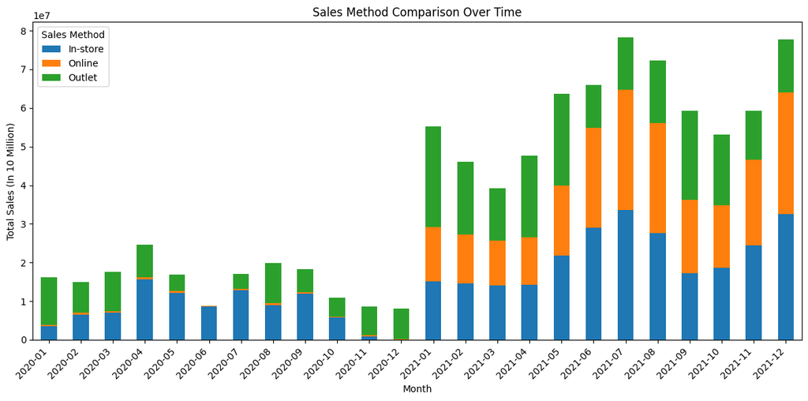

```python
# Sales Method Comparison
# Group data by 'YearMonth' and 'Sales Method', and sum 'Total Sales'
sales_by_method_over_time = sales.groupby(['YearMonth', 'Sales Method'])['Total Sales'].sum().unstack()

# Stacked bar graph
sales_by_method_over_time.plot(kind='bar', stacked=True, figsize=(12, 6))
plt.xlabel('Month')
plt.ylabel('Total Sales (In 10 Million)')
plt.title('Sales Method Comparison Over Time')
plt.xticks(rotation=45, ha='right')
plt.legend(title='Sales Method')
plt.tight_layout()
plt.show()
```

## Plot 11

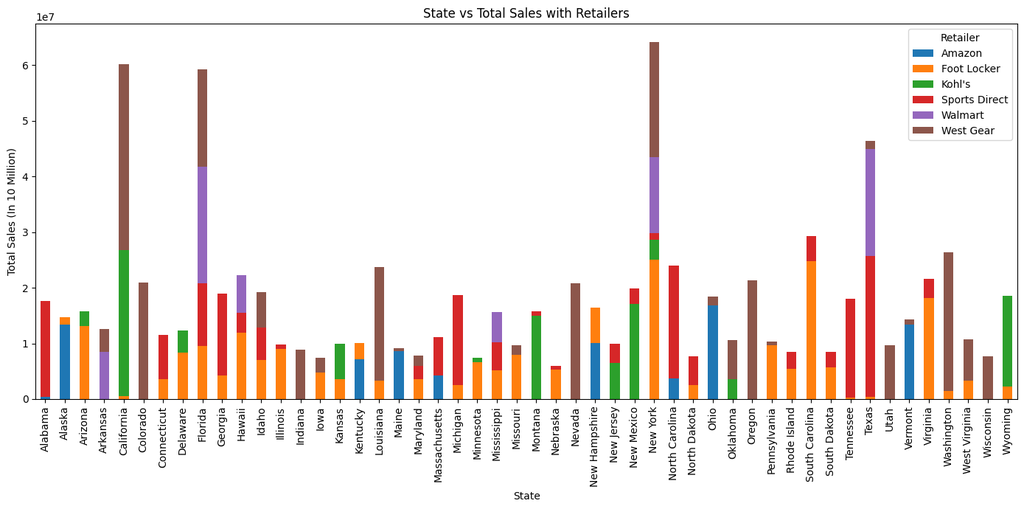

```python
# Stacked bar chart of sate vs total sales with retailers

# Group by State and Retailer ID, then sum Total Sales
sales_by_state_retailer = sales.groupby(['State', 'Retailer'])['Total Sales'].sum().unstack()

# Stacked bar chart
sales_by_state_retailer.plot(kind='bar', stacked=True, figsize=(14, 7))
plt.xlabel('State')
plt.ylabel('Total Sales (In 10 Million)')
plt.title('State vs Total Sales with Retailers')
plt.xticks(rotation=90)
plt.legend(title='Retailer', loc='upper right')
plt.tight_layout()
plt.show()
```

## Plot 12

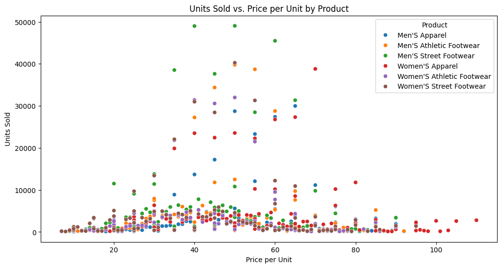

```python
# Units Sold vs. Price per Unit
# Group data by 'Product' and 'Price per Unit', then sum 'Units Sold'
sales_by_product_price = sales.groupby(['Product', 'Price per Unit'])['Units Sold'].sum().reset_index()

# Create a scatter plot for each product category
plt.figure(figsize=(12, 6))
sns.scatterplot(x='Price per Unit', y='Units Sold', hue='Product', data=sales_by_product_price)
plt.xlabel('Price per Unit')
plt.ylabel('Units Sold')
plt.title('Units Sold vs. Price per Unit by Product')
plt.show()
```

```python
# Assuming your original DataFrame is named 'sales'
new_df = sales.copy()

# Initialize LabelEncoder
le = LabelEncoder()

# Identify categorical columns
categorical_columns = new_df.select_dtypes(include=['object', 'category']).columns

# Perform label encoding on categorical columns
for col in categorical_columns:
    new_df[col] = le.fit_transform(new_df[col].astype(str))

# Display the first few rows of the new DataFrame
print(new_df.head())

# Display info about the new DataFrame
print(new_df.info())
```

```
   Retailer Invoice Date  Region  State  City  Product  Price per Unit  \
0         1   2020-01-01       1     31    35        2            50.0
1         5   2021-01-01       4      4    46        1            65.0
2         5   2021-01-02       4      4    46        5            65.0
3         5   2021-01-03       4      4    46        4            60.0
4         5   2021-01-04       4      4    46        0            65.0

   Units Sold  Total Sales  Operating Profit  Operating Margin  Sales Method  \
0        1200     600000.0          300000.0              0.50             0
1         750     487500.0          121875.0              0.25             2
2         750     487500.0          195000.0              0.40             2
3         650     390000.0          136500.0              0.35             2
4         550     357500.0          196625.0              0.55             2

   Year  Month  Season  Gender YearMonth
```

[output cut: 30 more lines]

### Plot 13

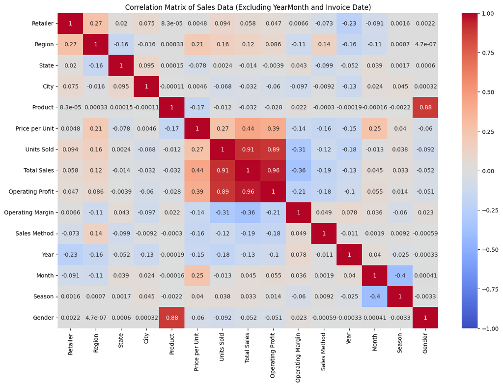

```python
columns_to_include = [col for col in new_df.columns if col not in ['YearMonth', 'Invoice Date']]

# Calculate the correlation matrix
correlation_matrix = new_df[columns_to_include].corr()

# Heatmap of the correlation matrix
plt.figure(figsize=(15, 10))
sns.heatmap(correlation_matrix, annot=True, cmap='coolwarm', vmin=-1, vmax=1, center=0)
plt.title('Correlation Matrix of Sales Data (Excluding YearMonth and Invoice Date)')
plt.show()
```

### Model 1

```python
X = sales[['Price per Unit', 'Units Sold', 'Operating Profit','Operating Margin','Year', 'Month']]  # relevant numeric features
y = sales['Total Sales'] # 'Total Sales' is the target variable

# Split data into training and testing sets
X_train, X_test, y_train, y_test = train_test_split(X, y, test_size=0.2, random_state=42)

# Random Forest Model
rf_model = RandomForestRegressor(n_estimators=100, random_state=42)
rf_model.fit(X_train, y_train)
rf_predictions = rf_model.predict(X_test)
rf_mse = mean_squared_error(y_test, rf_predictions)
rf_rmse= np.sqrt(rf_mse)
rf_r2 = r2_score(y_test, rf_predictions)

print("Random Forest Model:")
print(f"Mean Squared Error: {rf_mse}")
print(f"Root Mean Squared Error: {rf_rmse}")
print(f"R-squared: {rf_r2}")
```

```
Random Forest Model:
Mean Squared Error: 29658789.644945625
Root Mean Squared Error: 5445.98839926653
R-squared: 0.9985556569909194
```

```python
sales.columns
```

```
Index(['Retailer', 'Invoice Date', 'Region', 'State', 'City', 'Product',
       'Price per Unit', 'Units Sold', 'Total Sales', 'Operating Profit',
       'Operating Margin', 'Sales Method', 'Year', 'Month', 'Season', 'Gender',
       'YearMonth'],
      dtype='object')
```

### Model 2

```python
columns_to_include = [col for col in new_df.columns if col not in ['YearMonth','Units Sold', 'Invoice Date','Operating Profit','Season','Region','State','Year']]
sales=sales[columns_to_include]
```

```python
# Step 1: Prepare the data
le = LabelEncoder()
X = sales.drop(['Total Sales'], axis=1)  # 'Total Sales' is the target variable
y = sales['Total Sales']

for column in X.select_dtypes(include=['object', 'category']):
    X[column] = le.fit_transform(X[column].astype(str))

# Step 2: Split the data into training and testing sets
X_train, X_test, y_train, y_test = train_test_split(X, y, test_size=0.3, random_state=42)

# Step 3: Create and train the Random Forest model
rf_model = RandomForestRegressor(n_estimators=100, random_state=42)
rf_model.fit(X_train, y_train)

# Step 4: Make predictions
y_pred = rf_model.predict(X_test)

# Step 5: Evaluate the model
mse = mean_squared_error(y_test, y_pred)
rmse = np.sqrt(mse)
r2 = r2_score(y_test, y_pred)

print(f"Mean Squared Error: {mse}")
print(f"Root Mean Squared Error: {rmse}")
print(f"R-squared Score: {r2}")
```

```
Mean Squared Error: 2263966549.119561
Root Mean Squared Error: 47581.1575008381
R-squared Score: 0.8879674157435203
```

### Plot 14

```
Top 10 Most Important Features:
            feature  importance
3    Price per Unit    0.365618
4  Operating Margin    0.191392
5      Sales Method    0.139119
1              City    0.131613
2           Product    0.067908
6             Month    0.056230
0          Retailer    0.034122
7            Gender    0.013999
```

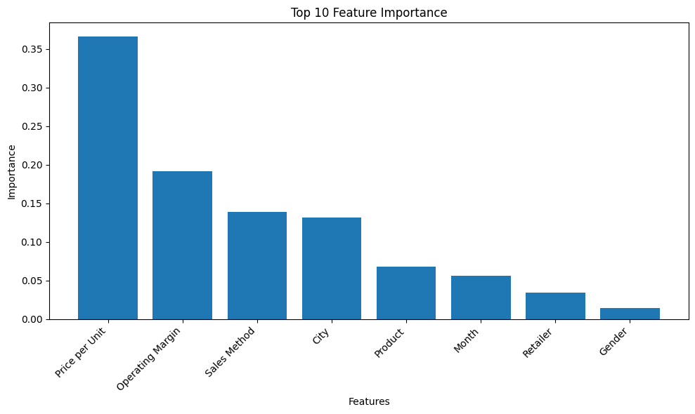

```python
# Feature Importance
feature_importance = pd.DataFrame({
    'feature': X.columns,
    'importance': rf_model.feature_importances_
}).sort_values('importance', ascending=False)

print("\nTop 10 Most Important Features:")
print(feature_importance.head(10))

# Visualize feature importance
plt.figure(figsize=(10, 6))
plt.bar(feature_importance['feature'][:10], feature_importance['importance'][:10])
plt.title('Top 10 Feature Importance')
plt.xlabel('Features')
plt.ylabel('Importance')
plt.xticks(rotation=45, ha='right')
plt.tight_layout()
plt.show()
```

### Plot 15

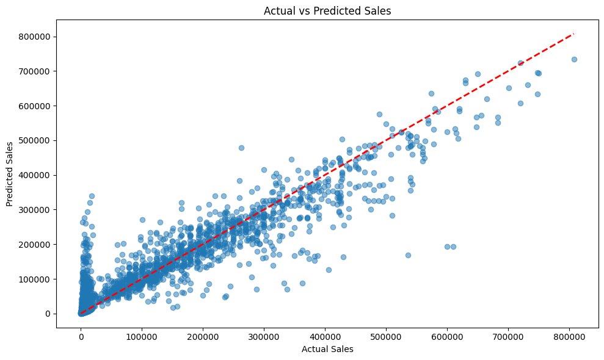

```python
# Visualize Actual vs Predicted values
plt.figure(figsize=(10, 6))
plt.scatter(y_test, y_pred, alpha=0.5)
plt.plot([y_test.min(), y_test.max()], [y_test.min(), y_test.max()], 'r--', lw=2)
plt.xlabel('Actual Sales')
plt.ylabel('Predicted Sales')
plt.title('Actual vs Predicted Sales')
plt.tight_layout()
plt.show()
```

### Model to predict sales for new product launches

```python
categorical_columns = sales[['Sales Method','City','Gender','Retailer']]
for col in categorical_columns:
    original_values = sales[col].unique()
    encoded_values = le.fit_transform(original_values)
    mapping = dict(zip(original_values, encoded_values))
    print(f"\nMapping for {col}:")
    print(mapping)
```

```
Mapping for Sales Method:
{'In-store': 0, 'Outlet': 2, 'Online': 1}

Mapping for City:
{'New York': 35, 'San Francisco': 46, 'Los Angeles': 28, 'Chicago': 13, 'Dallas': 15, 'Philadelphia': 40, 'Billings': 5, 'Knoxville': 25, 'Omaha': 38, 'Birmingham': 6, 'Portland': 42, 'Anchorage': 2, 'Honolulu': 21, 'Orlando': 39, 'Albany': 0, 'Cheyenne': 12, 'Richmond': 44, 'Detroit': 18, 'St. Loui…

Mapping for Gender:
{'Men': 0, 'Women': 1}

Mapping for Retailer:
{'Foot Locker': 1, 'West Gear': 5, "Kohl's": 2, 'Sports Direct': 3, 'Amazon': 0, 'Walmart': 4}
```

```python
# Select relevant features for prediction
features = ['Price per Unit','Operating Margin', 'Sales Method','City', 'Month','Retailer','Gender']
X = sales[features]
y = sales['Total Sales']

# Encode categorical variables
le = LabelEncoder()
for column in X.select_dtypes(include=['object', 'category']):
    X[column] = le.fit_transform(X[column])

# Split the data
X_train, X_test, y_train, y_test = train_test_split(X, y, test_size=0.2, random_state=42)

# Create and train the Random Forest model
rf_model = RandomForestRegressor(n_estimators=100, random_state=42)
rf_model.fit(X_train, y_train)

# Make predictions
y_pred = rf_model.predict(X_test)

# Evaluate the model
mse = mean_squared_error(y_test, y_pred)
rmse = np.sqrt(mse)
r2 = r2_score(y_test, y_pred)

print(f"Mean Squared Error: {mse}")
print(f"Root Mean Squared Error: {rmse}")
print(f"R-squared Score: {r2}")

# Feature importance
feature_importance = pd.DataFrame({
    'feature': features,
    'importance': rf_model.feature_importances_
}).sort_values('importance', ascending=False)

print("\nTop 5 Most Important Features:")
print(feature_importance.head())

# Predict sales for a new product or market
new_product = np.array([[30,10,1,35,12,0,0]])  # Example values
predicted_sales = rf_model.predict(new_product)
print(f"\nPredicted sales for new product in Dollars for one month: {predicted_sales[0]}")
```

```
Mean Squared Error: 2499995076.240165
Root Mean Squared Error: 49999.95076237741
R-squared Score: 0.8782536153926044

Top 5 Most Important Features:
            feature  importance
0    Price per Unit    0.370805
1  Operating Margin    0.202356
3              City    0.146841
2      Sales Method    0.144045
4             Month    0.068889

Predicted sales for new product in Dollars for one month: 9372.3
```

Based on the output, we can draw several conclusions about our Random Forest model for predicting sales of new product launches:

**Model Performance:**

R-squared Score: 0.87825 (87.825%)

This indicates that the model explains about 87.825% of the variance in the sales data, which is quite good. It suggests that the model has captured a significant portion of the underlying patterns in the data.

Root Mean Squared Error (RMSE): 49,999.95

This represents the average deviation of predictions from actual sales figures.

**Feature Importance:**

Price per Unit (37.08%): This is the most important feature, suggesting that pricing strategy has the biggest impact on sales.

Operating Margin (20.23%): The second most important feature, indicating that profitability is a key factor in sales performance.

City (14.68%): The location plays a significant role in sales, possibly due to different market conditions or consumer behaviors in various cities.

Sales Method (14.40%): The way products are sold also has a substantial impact on sales.

Month (6.88%): There's some seasonality in sales, but it's less important than other factors.

**Implications for New Product Launch:**

Pricing Strategy: Given the high importance of 'Price per Unit', careful consideration should be given to pricing new products.

Location-based Strategy: The importance of 'City' indicates that sales performance varies significantly by location.

Sales Channel Optimization: The significance of 'Sales Method' implies that choosing the right sales channels is crucial for new product success.

Seasonal Timing: While not the most critical factor, the month of launch does have some impact on sales performance.